# Testing the generality of host-symbiont cophylogeny

## Meta-regression

We ran a univaraite meta-regression model for each of following moderators: 1) `symbiosis`, 2) `host_tax_broad`, 3) `symbiont_tax_broad`, 4) `host_range_link_ratio`, 5) `host_range_taxonomic_breadth`, 6) `mode_of_transmission_broad`, and 7) `endo_or_ecto`. The results from these models are presented in the main text.

```r
dat %<>%
    # host_tax_broad*symbiosis (host_tax_symbiosis)
  mutate(host_tax_symbiosis = str_c(host_tax_broad, symbiosis),
         host_tax_symbiosis = ifelse(host_tax_symbiosis == "InvertNA", NA, host_tax_symbiosis),
         host_tax_symbiosis = factor(host_tax_symbiosis),
    # symbiont_tax_broad*symbiosis (symbiont_tax_symbiosis)
         symbiont_tax_symbiosis = factor(str_c(symbiont_tax_broad, symbiosis)),
    # host_tax_broad*symbiont_tax_broad (host_symbiont_tax)
         host_symbiont_tax  = factor(str_c(host_tax_broad, symbiont_tax_broad)),
    # symbiosis*mode_of_transmission_broad (symbiosis_transmission)
    symbiosis_transmission  = factor(str_c(symbiosis, mode_of_transmission_broad)))
```

### Univaraite (Uni-predictor) analyses

#### The type of symbiosis: parasitism vs. mutualism

```r
# meta-regression: mutiple intercepts
mr_symbiosis1 <- rma.mv(yi = Zr, V = VZr, mods = ~symbiosis - 1, test = "t",
    random = ~1 | authors, data = dat)
# meta-regression: contrast
mr_symbiosis2 <- rma.mv(yi = Zr, V = VZr, mods = ~symbiosis, test = "t", random = ~1 |
    authors, data = dat)
```

**Supplementary Table 2:** Regression coefficients (Estimate), 95% confidence intervals (CIs), variance components (V) and variance examplained, *R*<sup>2</sup><sub>[marginal]</sub> (R2) from the meta-regression with `symbiosis`.

```r
# getting marginal R2
r2_symbiosis1 <- R2(mr_symbiosis1)

# getting estimates
res_symbiosis1 <- get_est(mr_symbiosis1, mod = "symbiosis")
res_symbiosis2 <- get_est(mr_symbiosis2, mod = "symbiosis")

# creating a table
tibble(`Fixed effect` = c(as.character(res_symbiosis1$name), cont_gen(res_symbiosis1$name)),
    Estimate = c(res_symbiosis1$estimate, res_symbiosis2$estimate[2]), `Lower CI [0.025]` = c(res_symbiosis1$lowerCL,
        res_symbiosis2$lowerCL[2]), `Upper CI  [0.975]` = c(res_symbiosis1$upperCL,
        res_symbiosis2$upperCL[2]), `V[authors]` = c(mr_symbiosis1$sigma2, rep(NA,
        2)), R2 = c(r2_symbiosis1[1], rep(NA, 2))) %>% kable("html", digits = 3) %>%
    kable_styling("striped", position = "left")
```

| Fixed effect | Estimate | Lower CI [0.025] | Upper CI [0.975] | V[authors] | R2 |
| --- | --- | --- | --- | --- | --- |
| Mutualist | 0.411 | 0.349 | 0.473 | 0.031 | 0.064 |
| Parasite | 0.311 | 0.268 | 0.354 | NA | NA |
| Mutualist-Parasite | -0.100 | -0.174 | -0.026 | NA | NA |

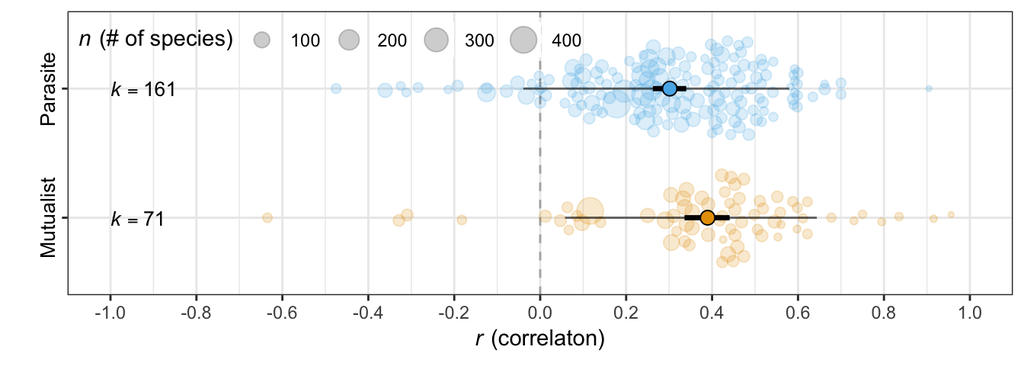

```r
# adding sample size (k) for each category
k_symbiosis <- dat %>% group_by(symbiosis) %>% count()
# getting estimates and predicitons
pred_symbiosis <- get_pred(mr_symbiosis1, mod = "symbiosis")
res_symbiosis1 <- left_join(res_symbiosis1, k_symbiosis, by =  c("name" = "symbiosis"))  %>% left_join(pred_symbiosis)
#res_symbiosis1
# drawing a funnel plot - fig 2b
fig_symbiosis <- ggplot(data = res_symbiosis1, aes(x = tanh(estimate), y = name)) +
  scale_x_continuous(limits=c(-1, 1), breaks = seq(-1, 1, by = 0.2) ) +
  geom_quasirandom(data = dat %>% filter(!is.na(symbiosis)),
                   aes(x= tanh(Zr), y = symbiosis, size = ((1/VZr) + 3), colour = symbiosis), groupOnX = FALSE, alpha=0.2) +
  # 95 %precition interval (PI)
  geom_errorbarh(aes(xmin = tanh(lowerPR), xmax = tanh(upperPR)),  height = 0, show.legend = F, size = 0.5, alpha = 0.6) +
  # 95 %CI
  geom_errorbarh(aes(xmin = tanh(lowerCL), xmax = tanh(upperCL)),  height = 0, show.legend = F, size = 1.2) +
  geom_vline(xintercept = 0, linetype = 2, colour = "black", alpha = 0.3) +
  # creating dots and different size (bee-swarm and bubbles)
  geom_point(aes(fill = name), size = 3, shape = 21) + #
  # setting colours
  scale_color_manual(values = c("Mutualist" = "#E69F00", "Parasite" = "#56B4E9")) +
  scale_fill_manual(values = c("Mutualist" = "#E69F00", "Parasite" = "#56B4E9")) +
  annotate('text', x = -1, y = res_symbiosis1$name, label= paste("italic(k)==", res_symbiosis1$n), parse=TRUE, hjust = "left", size=3.5) +
  labs(x = expression(paste(italic(r), " (correlaton)")), y = "", size = expression(paste(italic(n), " (# of species)")) ) +
  guides(fill = "none", colour = "none") +
  theme_bw() +
  theme(legend.position= c(0, 1), legend.justification = c(0,1)) +
  theme(legend.direction="horizontal") +
  #theme(legend.background = element_rect(fill = "white", colour = "black")) +
  theme(legend.background = element_blank()) +
  theme(axis.text.y = element_text(size = 10, colour ="black", hjust = 0.5, angle = 90))

fig_symbiosis
```

#### The effect of host taxa

```r
# reordering
dat$host_tax_broad <- factor(dat$host_tax_broad, levels = c("Microbe", "Plant",
    "Invert", "Vert"))

# sizes <- factor(sizes, levels = c('small', 'medium', 'large')) sizes > [1]
# small large large small medium > Levels: small medium large
# meta-regression: mutiple intercepts
mr_host_tax_broad1 <- rma.mv(yi = Zr, V = VZr, mods = ~host_tax_broad - 1, test = "t",
    random = ~1 | authors, data = dat)

# meta-regression: contrast 1
mr_host_tax_broad2 <- rma.mv(yi = Zr, V = VZr, mods = ~host_tax_broad, test = "t",
    random = ~1 | authors, data = dat)

# meta-regression: contrast 2
mr_host_tax_broad3 <- rma.mv(yi = Zr, V = VZr, mods = ~relevel(host_tax_broad,
    ref = "Plant"), test = "t", random = ~1 | authors, data = dat)

# meta-regression: contrast 3
mr_host_tax_broad4 <- rma.mv(yi = Zr, V = VZr, mods = ~relevel(host_tax_broad,
    ref = "Invert"), test = "t", random = ~1 | authors, data = dat)
```

**Supplementary Table 3:** Regression coefficients (Estimate), 95% confidence intervals (CIs), variance components (V) and variance examplained, *R*<sup>2</sup><sub>[marginal]</sub> (R2) from the meta-regression with `host_tax_broad`.

```r
# getting marginal R2
r2_host_tax_broad1 <- R2(mr_host_tax_broad1)

# getting estimates
res_host_tax_broad1 <- get_est(mr_host_tax_broad1, mod = "host_tax_broad")
res_host_tax_broad2 <- get_est(mr_host_tax_broad2, mod = "host_tax_broad")
# the name bit does not work if relevel....
res_host_tax_broad3 <- get_est(mr_host_tax_broad3, mod = "host_tax_broad")
res_host_tax_broad4 <- get_est(mr_host_tax_broad4, mod = "host_tax_broad")

# creating a table
tibble(`Fixed effect` = c(as.character(res_host_tax_broad1$name), cont_gen(res_host_tax_broad1$name)),
    Estimate = c(res_host_tax_broad1$estimate, res_host_tax_broad2$estimate[-1],
        res_host_tax_broad3$estimate[-(1:2)], res_host_tax_broad4$estimate[-(1:3)]),
    `Lower CI [0.025]` = c(res_host_tax_broad1$lowerCL, res_host_tax_broad2$lowerCL[-1],
        res_host_tax_broad3$lowerCL[-(1:2)], res_host_tax_broad4$lowerCL[-(1:3)]),
    `Upper CI  [0.975]` = c(res_host_tax_broad1$upperCL, res_host_tax_broad2$upperCL[-1],
        res_host_tax_broad3$upperCL[-(1:2)], res_host_tax_broad4$upperCL[-(1:3)]),
    `V[authors]` = c(mr_host_tax_broad1$sigma2, rep(NA, 9)), R2 = c(r2_host_tax_broad1[1],
        rep(NA, 9))) %>% kable("html", digits = 3) %>% kable_styling("striped",
    position = "left") %>% scroll_box(width = "100%", height = "300px")
```

| Fixed effect | Estimate | Lower CI [0.025] | Upper CI [0.975] | V[authors] | R2 |
| --- | --- | --- | --- | --- | --- |
| Microbe | 0.557 | 0.404 | 0.710 | 0.03 | 0.168 |
| Plant | 0.244 | 0.168 | 0.321 | NA | NA |
| Invert | 0.412 | 0.344 | 0.480 | NA | NA |
| Vert | 0.327 | 0.277 | 0.378 | NA | NA |
| Microbe-Plant | -0.312 | -0.483 | -0.141 | NA | NA |
| Microbe-Invert | -0.144 | -0.312 | 0.023 | NA | NA |
| Microbe-Vert | -0.229 | -0.390 | -0.068 | NA | NA |
| Plant-Invert | 0.168 | 0.065 | 0.270 | NA | NA |
| Plant-Vert | 0.083 | -0.009 | 0.175 | NA | NA |
| Invert-Vert | -0.085 | -0.168 | -0.002 | NA | NA |

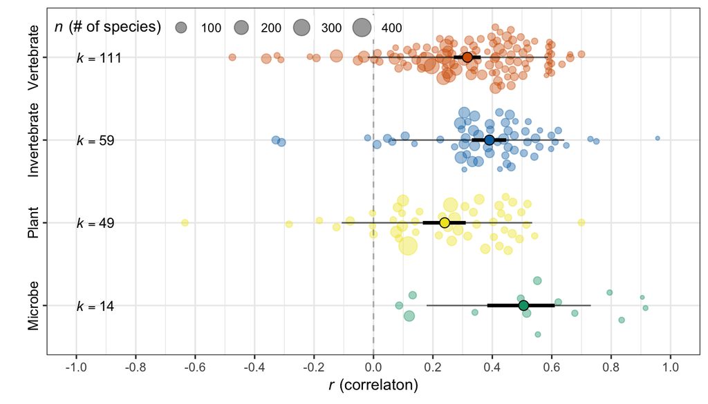

```r
# adding sample size (k) for each category
k_host_tax_broad <- dat %>% group_by(host_tax_broad) %>% count()
# getting estimates and predicitons
pred_host_tax_broad <- get_pred(mr_host_tax_broad1, mod = "host_tax_broad")
res_host_tax_broad1 <- left_join(res_host_tax_broad1, k_host_tax_broad, by =  c("name" = "host_tax_broad"))  %>% left_join(pred_host_tax_broad)
#res_symbiosis1
# drawing a funnel plot - fig 2b
fig_host_tax_broad <- ggplot(data = res_host_tax_broad1, aes(x = tanh(estimate), y = name)) +
  scale_x_continuous(limits=c(-1, 1), breaks = seq(-1, 1, by = 0.2) ) +
  geom_quasirandom(data = dat %>% filter(!is.na(host_tax_broad)),
                   aes(x= tanh(Zr), y = host_tax_broad, size = ((1/VZr) + 3), colour = host_tax_broad), groupOnX = FALSE, alpha=0.4) +
  # 95 %precition interval (PI)
  geom_errorbarh(aes(xmin = tanh(lowerPR), xmax = tanh(upperPR)),  height = 0, show.legend = F, size = 0.5, alpha = 0.6) +
  # 95 %CI
  geom_errorbarh(aes(xmin = tanh(lowerCL), xmax = tanh(upperCL)),  height = 0, show.legend = F, size = 1.2) +
  geom_vline(xintercept = 0, linetype = 2, colour = "black", alpha = 0.3) +
  # creating dots and different size (bee-swarm and bubbles)
  geom_point(aes(fill = name), size = 3, shape = 21) + #
  # setting colours
  scale_color_manual(values = c("Microbe" = "#009E73",  "Plant" = "#F0E422",  "Invert"= "#0072B2",  "Vert" = "#D55E00")) +
  scale_fill_manual(values = c("Microbe" = "#009E73",  "Plant" = "#F0E422",  "Invert"= "#0072B2",  "Vert" = "#D55E00")) +
  scale_y_discrete(labels = c("Microbe" = "Microbe",  "Plant" = "Plant",  "Invert"= "Invertebrate",  "Vert" = "Vertebrate")) +
  annotate('text', x = -1, y = res_host_tax_broad1$name, label= paste("italic(k)==", res_host_tax_broad1$n), parse=TRUE, hjust = "left", size=3.5) +
  labs(x = expression(paste(italic(r), " (correlaton)")), y = "", size = expression(paste(italic(n), " (# of species)")) ) +
  guides(fill = "none", colour = "none") +
  theme_bw() +
  theme(legend.position= c(0, 1), legend.justification = c(0,1)) +
  theme(legend.direction="horizontal") +
  #theme(legend.background = element_rect(fill = "white", colour = "black")) +
  theme(legend.background = element_blank()) +
  theme(axis.text.y = element_text(size = 10, colour ="black", hjust = 0.5, angle = 90))

fig_host_tax_broad
```

#### The effect of symbiont taxa

```r
# reordering
dat$symbiont_tax_broad <- factor(dat$symbiont_tax_broad, levels = c("Microbe",
    "Plant", "Invert", "Vert"))

# sizes <- factor(sizes, levels = c('small', 'medium', 'large')) sizes > [1]
# small large large small medium > Levels: small medium large
# meta-regression: mutiple intercepts
mr_symbiont_tax_broad1 <- rma.mv(yi = Zr, V = VZr, mods = ~symbiont_tax_broad -
    1, test = "t", random = ~1 | authors, data = dat)

# meta-regression: contrast 1
mr_symbiont_tax_broad2 <- rma.mv(yi = Zr, V = VZr, mods = ~symbiont_tax_broad,
    test = "t", random = ~1 | authors, data = dat)

# meta-regression: contrast 2
mr_symbiont_tax_broad3 <- rma.mv(yi = Zr, V = VZr, mods = ~relevel(symbiont_tax_broad,
    ref = "Plant"), test = "t", random = ~1 | authors, data = dat)

# meta-regression: contrast 3
mr_symbiont_tax_broad4 <- rma.mv(yi = Zr, V = VZr, mods = ~relevel(symbiont_tax_broad,
    ref = "Invert"), test = "t", random = ~1 | authors, data = dat)
```

**Supplementary Table 3:** Regression coefficients (Estimate), 95% confidence intervals (CIs), variance components (V) and variance examplained, *R*<sup>2</sup><sub>[marginal]</sub> (R2) from the meta-regression with `symbiont_tax_broad`.

```r
# getting marginal R2
r2_symbiont_tax_broad1 <- R2(mr_symbiont_tax_broad1)

# getting estimates
res_symbiont_tax_broad1 <- get_est(mr_symbiont_tax_broad1, mod = "symbiont_tax_broad")
res_symbiont_tax_broad2 <- get_est(mr_symbiont_tax_broad2, mod = "symbiont_tax_broad")
res_symbiont_tax_broad3 <- get_est(mr_symbiont_tax_broad3, mod = "symbiont_tax_broad")
res_symbiont_tax_broad4 <- get_est(mr_symbiont_tax_broad4, mod = "symbiont_tax_broad")

# creating a table
tibble(`Fixed effect` = c(as.character(res_symbiont_tax_broad1$name), cont_gen(res_symbiont_tax_broad1$name)),
    Estimate = c(res_symbiont_tax_broad1$estimate, res_symbiont_tax_broad2$estimate[-1],
        res_symbiont_tax_broad3$estimate[-(1:2)], res_symbiont_tax_broad4$estimate[-(1:3)]),
    `Lower CI [0.025]` = c(res_symbiont_tax_broad1$lowerCL, res_symbiont_tax_broad2$lowerCL[-1],
        res_symbiont_tax_broad3$lowerCL[-(1:2)], res_symbiont_tax_broad4$lowerCL[-(1:3)]),
    `Upper CI  [0.975]` = c(res_symbiont_tax_broad1$upperCL, res_symbiont_tax_broad2$upperCL[-1],
        res_symbiont_tax_broad3$upperCL[-(1:2)], res_symbiont_tax_broad4$upperCL[-(1:3)]),
    `V[authors]` = c(mr_symbiont_tax_broad1$sigma2, rep(NA, 9)), R2 = c(r2_symbiont_tax_broad1[1],
        rep(NA, 9))) %>% kable("html", digits = 3) %>% kable_styling("striped",
    position = "left") %>% scroll_box(width = "100%", height = "300px")
```

| Fixed effect | Estimate | Lower CI [0.025] | Upper CI [0.975] | V[authors] | R2 |
| --- | --- | --- | --- | --- | --- |
| Microbe | 0.353 | 0.303 | 0.403 | 0.032 | 0.082 |
| Plant | 0.733 | 0.440 | 1.026 | NA | NA |
| Invert | 0.322 | 0.268 | 0.375 | NA | NA |
| Vert | 0.355 | 0.056 | 0.654 | NA | NA |
| Microbe-Plant | 0.380 | 0.083 | 0.678 | NA | NA |
| Microbe-Invert | -0.031 | -0.104 | 0.042 | NA | NA |
| Microbe-Vert | 0.002 | -0.301 | 0.305 | NA | NA |
| Plant-Invert | -0.411 | -0.709 | -0.113 | NA | NA |
| Plant-Vert | -0.378 | -0.797 | 0.041 | NA | NA |
| Invert-Vert | 0.033 | -0.271 | 0.337 | NA | NA |

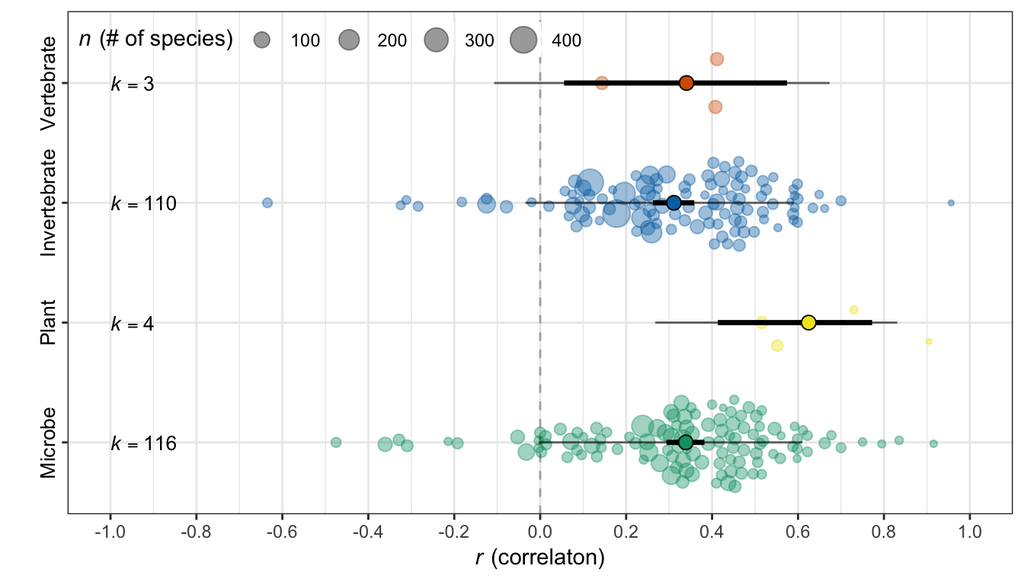

```r
# adding sample size (k) for each category
k_symbiont_tax_broad <- dat %>% group_by(symbiont_tax_broad) %>% count()
# getting estimates and predicitons
pred_symbiont_tax_broad <- get_pred(mr_symbiont_tax_broad1, mod = "symbiont_tax_broad")
res_symbiont_tax_broad1 <- left_join(res_symbiont_tax_broad1, k_symbiont_tax_broad, by =  c("name" = "symbiont_tax_broad"))  %>% left_join(pred_symbiont_tax_broad)
#res_symbiosis1
# drawing a funnel plot - fig 2b
fig_symbiont_tax_broad <- ggplot(data = res_symbiont_tax_broad1, aes(x = tanh(estimate), y = name)) +
  scale_x_continuous(limits=c(-1, 1), breaks = seq(-1, 1, by = 0.2) ) +
  geom_quasirandom(data = dat %>% filter(!is.na(symbiont_tax_broad)),
                   aes(x= tanh(Zr), y = symbiont_tax_broad, size = ((1/VZr) + 3), colour = symbiont_tax_broad), groupOnX = FALSE, alpha=0.4) +
  # 95 %precition interval (PI)
  geom_errorbarh(aes(xmin = tanh(lowerPR), xmax = tanh(upperPR)),  height = 0, show.legend = F, size = 0.5, alpha = 0.6) +
  # 95 %CI
  geom_errorbarh(aes(xmin = tanh(lowerCL), xmax = tanh(upperCL)),  height = 0, show.legend = F, size = 1.2) +
  geom_vline(xintercept = 0, linetype = 2, colour = "black", alpha = 0.3) +
  # creating dots and different size (bee-swarm and bubbles)
  geom_point(aes(fill = name), size = 3, shape = 21) + #
  # setting colours
  scale_color_manual(values = c("Microbe" = "#009E73",  "Plant" = "#F0E422",  "Invert"= "#0072B2",  "Vert" = "#D55E00" )) +
  scale_fill_manual(values = c("Microbe" = "#009E73",  "Plant" = "#F0E422",  "Invert"= "#0072B2",  "Vert" = "#D55E00")) +
  scale_y_discrete(labels = c("Microbe" = "Microbe",  "Plant" = "Plant",  "Invert"= "Invertebrate",  "Vert" = "Vertebrate")) +
  annotate('text', x = -1, y = res_symbiont_tax_broad1$name, label= paste("italic(k)==", res_symbiont_tax_broad1$n), parse=TRUE, hjust = "left", size=3.5) +
  labs(x = expression(paste(italic(r), " (correlaton)")), y = "", size = expression(paste(italic(n), " (# of species)")) ) +
  guides(fill = "none", colour = "none") +
  theme_bw() +
  theme(legend.position= c(0, 1), legend.justification = c(0,1)) +
  theme(legend.direction="horizontal") +
  #theme(legend.background = element_rect(fill = "white", colour = "black")) +
  theme(legend.background = element_blank()) +
  theme(axis.text.y = element_text(size = 10, colour ="black", hjust = 0.5, angle = 90))

fig_symbiont_tax_broad
```

#### Testing specialization 1: host range

Here are links for how to do confidence regions for rma.mv regression lines

https://www.rdocumentation.org/packages/metafor/versions/1.9-9/topics/predict.rma

https://stackoverflow.com/questions/50804464/out-of-sample-prediction-for-rma-object-in-metafor

#### The effect of the model of transmission

```r
# meta-regression: mutiple intercepts
mr_mode_of_transmission_broad1 <- rma.mv(yi = Zr, V = VZr, mods = ~mode_of_transmission_broad -
    1, test = "t", random = ~1 | authors, data = dat)

# meta-regression: contrast 1
mr_mode_of_transmission_broad2 <- rma.mv(yi = Zr, V = VZr, mods = ~mode_of_transmission_broad,
    test = "t", random = ~1 | authors, data = dat)

# meta-regression: contrast 2
mr_mode_of_transmission_broad3 <- rma.mv(yi = Zr, V = VZr, mods = ~relevel(mode_of_transmission_broad,
    ref = "vertical"), test = "t", random = ~1 | authors, data = dat)
```

**Supplementary Table 3:** Regression coefficients (Estimate), 95% confidence intervals (CIs), variance components (V) and variance examplained, *R*<sup>2</sup><sub>[marginal]</sub> (R2) from the meta-regression with `mode_of_transmission_broad`.

```r
# getting marginal R2
r2_mode_of_transmission_broad1 <- R2(mr_mode_of_transmission_broad1)

# getting estimates
res_mode_of_transmission_broad1 <- get_est(mr_mode_of_transmission_broad1, mod = "mode_of_transmission_broad")
res_mode_of_transmission_broad2 <- get_est(mr_mode_of_transmission_broad2, mod = "mode_of_transmission_broad")
res_mode_of_transmission_broad3 <- get_est(mr_mode_of_transmission_broad3, mod = "mode_of_transmission_broad")

# creating a table
tibble(`Fixed effect` = c(as.character(res_mode_of_transmission_broad1$name),
    cont_gen(res_mode_of_transmission_broad1$name)), Estimate = c(res_mode_of_transmission_broad1$estimate,
    res_mode_of_transmission_broad2$estimate[-1], res_mode_of_transmission_broad3$estimate[-(1:2)]),
    `Lower CI [0.025]` = c(res_mode_of_transmission_broad1$lowerCL, res_mode_of_transmission_broad2$lowerCL[-1],
        res_mode_of_transmission_broad3$lowerCL[-(1:2)]), `Upper CI  [0.975]` = c(res_mode_of_transmission_broad1$upperCL,
        res_mode_of_transmission_broad2$upperCL[-1], res_mode_of_transmission_broad3$upperCL[-(1:2)]),
    `V[authors]` = c(mr_mode_of_transmission_broad1$sigma2, rep(NA, 5)), R2 = c(r2_mode_of_transmission_broad1[1],
        rep(NA, 5))) %>% kable("html", digits = 3) %>% kable_styling("striped",
    position = "left")
```

[output not shown]

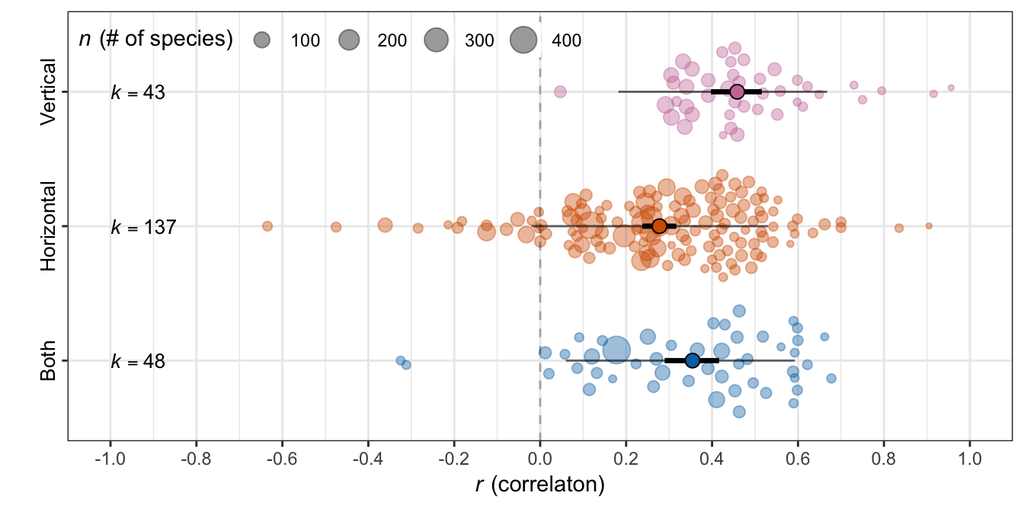

```r
# adding sample size (k) for each category
k_mode_of_transmission_broad <- dat %>% group_by(mode_of_transmission_broad) %>% count()
# getting estimates and predicitons
pred_mode_of_transmission_broad <- get_pred(mr_mode_of_transmission_broad1, mod = "mode_of_transmission_broad")
res_mode_of_transmission_broad1 <- left_join(res_mode_of_transmission_broad1, k_mode_of_transmission_broad, by =  c("name" = "mode_of_transmission_broad"))  %>% left_join(pred_mode_of_transmission_broad)
#res_symbiosis1
# drawing a funnel plot - fig 2b
fig_mode_of_transmission_broad <- ggplot(data = res_mode_of_transmission_broad1, aes(x = tanh(estimate), y = name)) +
  scale_x_continuous(limits=c(-1, 1), breaks = seq(-1, 1, by = 0.2) ) +
  geom_quasirandom(data = dat %>% filter(!is.na(mode_of_transmission_broad)),
                   aes(x= tanh(Zr), y = mode_of_transmission_broad, size = ((1/VZr) + 3), colour = mode_of_transmission_broad), groupOnX = FALSE, alpha=0.4) +
  # 95 %precition interval (PI)
  geom_errorbarh(aes(xmin = tanh(lowerPR), xmax = tanh(upperPR)),  height = 0, show.legend = F, size = 0.5, alpha = 0.6) +
  # 95 %CI
  geom_errorbarh(aes(xmin = tanh(lowerCL), xmax = tanh(upperCL)),  height = 0, show.legend = F, size = 1.2) +
  geom_vline(xintercept = 0, linetype = 2, colour = "black", alpha = 0.3) +
  # creating dots and different size (bee-swarm and bubbles)
  geom_point(aes(fill = name), size = 3, shape = 21) + #
  # setting colours
  scale_color_manual(values = c("both" = "#0072B2",  "horizontal" = "#D55E00",  "vertical"= "#CC79A7")) +
  scale_fill_manual(values = c("both" = "#0072B2",  "horizontal" = "#D55E00",  "vertical"= "#CC79A7")) +
  scale_y_discrete(labels = c("both" = "Both",  "horizontal" = "Horizontal",  "vertical"= "Vertical")) +
  annotate('text', x = -1, y = res_mode_of_transmission_broad1$name, label= paste("italic(k)==", res_mode_of_transmission_broad1$n), parse=TRUE, hjust = "left", size=3.5) +
  labs(x = expression(paste(italic(r), " (correlaton)")), y = "", size = expression(paste(italic(n), " (# of species)")) ) +
  guides(fill = "none", colour = "none") +
  theme_bw() +
  theme(legend.position= c(0, 1), legend.justification = c(0,1)) +
  theme(legend.direction = "horizontal") +
  #theme(legend.background = element_rect(fill = "white", colour = "black")) +
  theme(legend.background = element_blank()) +
  theme(axis.text.y = element_text(size = 10, colour ="black", hjust = 0.5, angle = 90))

fig_mode_of_transmission_broad
```

#### The effect of the type of symbiosis: endosymbiosis vs. ectosymbiosis

```r
# reordering
dat$endo_or_ecto <- factor(dat$endo_or_ecto, levels = c("Endo/Ecto", "Endo",
    "Ecto"))

# meta-regression: mutiple intercepts
mr_endo_or_ecto1 <- rma.mv(yi = Zr, V = VZr, mods = ~endo_or_ecto - 1, test = "t",
    random = ~1 | authors, data = dat)

# meta-regression: contrast 1
mr_endo_or_ecto2 <- rma.mv(yi = Zr, V = VZr, mods = ~endo_or_ecto, test = "t",
    random = ~1 | authors, data = dat)

# meta-regression: contrast 2
mr_endo_or_ecto3 <- rma.mv(yi = Zr, V = VZr, mods = ~relevel(endo_or_ecto, ref = "Endo"),
    test = "t", random = ~1 | authors, data = dat)
```

**Supplementary Table 3:** Regression coefficients (Estimate), 95% confidence intervals (CIs), variance components (V) and variance examplained, *R*<sup>2</sup><sub>[marginal]</sub> (R2) from the meta-regression with `endo_or_ecto`.

```r
# getting marginal R2
r2_endo_or_ecto1 <- R2(mr_endo_or_ecto1)

# getting estimates
res_endo_or_ecto1 <- get_est(mr_endo_or_ecto1, mod = "endo_or_ecto")
res_endo_or_ecto2 <- get_est(mr_endo_or_ecto2, mod = "endo_or_ecto")
res_endo_or_ecto3 <- get_est(mr_endo_or_ecto3, mod = "endo_or_ecto")

# creating a table
tibble(`Fixed effect` = c(as.character(res_endo_or_ecto1$name), cont_gen(res_endo_or_ecto1$name)),
    Estimate = c(res_endo_or_ecto1$estimate, res_endo_or_ecto2$estimate[-1],
        res_endo_or_ecto3$estimate[-(1:2)]), `Lower CI [0.025]` = c(res_endo_or_ecto1$lowerCL,
        res_endo_or_ecto2$lowerCL[-1], res_endo_or_ecto3$lowerCL[-(1:2)]), `Upper CI  [0.975]` = c(res_endo_or_ecto1$upperCL,
        res_endo_or_ecto2$upperCL[-1], res_endo_or_ecto3$upperCL[-(1:2)]), `V[authors]` = c(mr_endo_or_ecto1$sigma2,
        rep(NA, 5)), R2 = c(r2_endo_or_ecto1[1], rep(NA, 5))) %>% kable("html",
    digits = 3) %>% kable_styling("striped", position = "left")
```

| Fixed effect | Estimate | Lower CI [0.025] | Upper CI [0.975] | V[authors] | R2 |
| --- | --- | --- | --- | --- | --- |
| Endo/Ecto | 0.334 | 0.035 | 0.632 | 0.034 | 0.001 |
| Endo | 0.342 | 0.298 | 0.387 | NA | NA |
| Ecto | 0.353 | 0.287 | 0.418 | NA | NA |
| Endo/Ecto-Endo | 0.009 | -0.293 | 0.311 | NA | NA |
| Endo/Ecto-Ecto | 0.019 | -0.287 | 0.325 | NA | NA |
| Endo-Ecto | 0.010 | -0.069 | 0.090 | NA | NA |

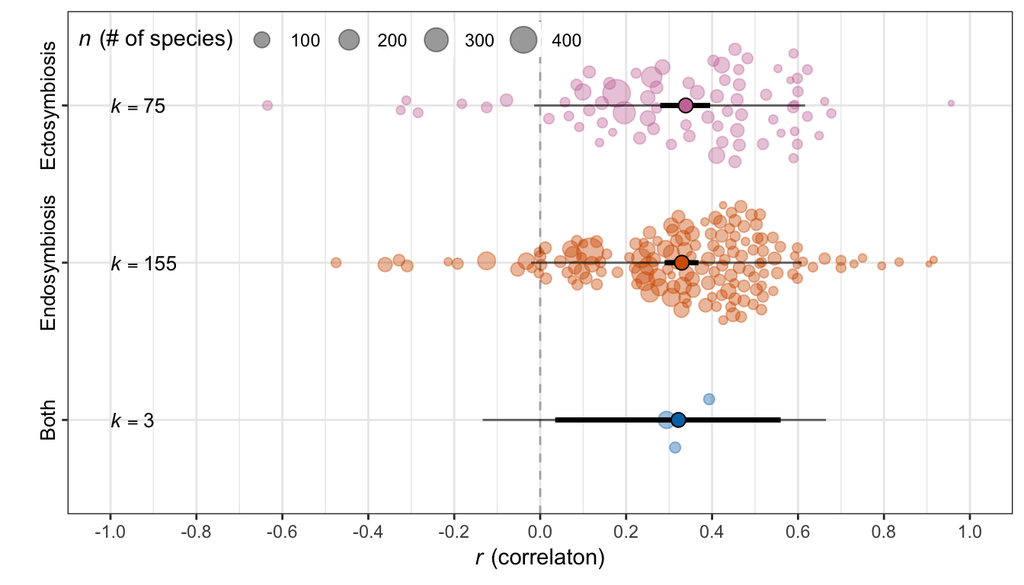

```r
# adding sample size (k) for each category
k_endo_or_ecto <- dat %>% group_by(endo_or_ecto) %>% count()
# getting estimates and predicitons
pred_endo_or_ecto <- get_pred(mr_endo_or_ecto1, mod = "endo_or_ecto")
res_endo_or_ecto1 <- left_join(res_endo_or_ecto1, k_endo_or_ecto, by =  c("name" = "endo_or_ecto"))  %>% left_join(pred_endo_or_ecto)
#res_symbiosis1
# drawing a funnel plot - fig 2b
fig_endo_or_ecto <- ggplot(data = res_endo_or_ecto1, aes(x = tanh(estimate), y = name)) +
  scale_x_continuous(limits=c(-1, 1), breaks = seq(-1, 1, by = 0.2) ) +
  geom_quasirandom(data = dat %>% filter(!is.na(endo_or_ecto)),
                   aes(x= tanh(Zr), y = endo_or_ecto, size = ((1/VZr) + 3), colour = endo_or_ecto), groupOnX = FALSE, alpha=0.4) +
  # 95 %precition interval (PI)
  geom_errorbarh(aes(xmin = tanh(lowerPR), xmax = tanh(upperPR)),  height = 0, show.legend = F, size = 0.5, alpha = 0.6) +
  # 95 %CI
  geom_errorbarh(aes(xmin = tanh(lowerCL), xmax = tanh(upperCL)),  height = 0, show.legend = F, size = 1.2) +
  geom_vline(xintercept = 0, linetype = 2, colour = "black", alpha = 0.3) +
  # creating dots and different size (bee-swarm and bubbles)
  geom_point(aes(fill = name), size = 3, shape = 21) + #
  # setting colours
  scale_color_manual(values = c("Endo/Ecto" = "#0072B2",  "Endo" = "#D55E00",  "Ecto"= "#CC79A7")) +
  scale_fill_manual(values = c("Endo/Ecto" = "#0072B2",  "Endo" = "#D55E00",  "Ecto"= "#CC79A7")) +
  scale_y_discrete(labels = c("Endo/Ecto" = "Both",  "Endo" = "Endosymbiosis",  "Ecto"= "Ectosymbiosis")) +
  annotate('text', x = -1, y = res_endo_or_ecto1$name, label= paste("italic(k)==", res_endo_or_ecto1$n), parse=TRUE, hjust = "left", size=3.5) +
  labs(x = expression(paste(italic(r), " (correlaton)")), y = "", size = expression(paste(italic(n), " (# of species)")) ) +
  guides(fill = "none", colour = "none") +
  theme_bw() +
  theme(legend.position= c(0, 1), legend.justification = c(0,1)) +
  theme(legend.direction = "horizontal") +
  #theme(legend.background = element_rect(fill = "white", colour = "black")) +
  theme(legend.background = element_blank()) +
  theme(axis.text.y = element_text(size = 10, colour ="black", hjust = 0.5, angle = 90))

fig_endo_or_ecto
```

#### The combined effect of host taxa and symbiosis (parasitism vs. mutualism)

```r
# reordering
dat$host_tax_symbiosis <- factor(dat$host_tax_symbiosis, levels = c("MicrobeMutualist",
    "MicrobeParasite", "PlantMutualist", "PlantParasite", "InvertMutualist",
    "InvertParasite", "VertMutualist", "VertParasite"))

# meta-regression: mutiple intercepts
mr_host_tax_symbiosis1 <- rma.mv(yi = Zr, V = VZr, mods = ~host_tax_symbiosis -
    1, test = "t", random = ~1 | authors, data = dat)

# # meta-regression: contrasts x 10 getting the level names out
level_names <- levels(dat$host_tax_symbiosis)

# helper function to run metafor meta-regression
run_rma <- function(name) {
    rma.mv(yi = Zr, V = VZr, mods = ~relevel(host_tax_symbiosis, ref = name),
        test = "t", random = ~1 | authors, data = dat)
}

# results of meta-regression including all contrast results; taking the last
# level out ([-length(level_names)])
mr_host_tax_symbiosis <- map(level_names[-length(level_names)], run_rma)
```

```r
# getting marginal R2
r2_host_tax_symbiosis1 <- R2(mr_host_tax_symbiosis1)

# getting estimates
res_host_tax_symbiosis1 <- get_est(mr_host_tax_symbiosis1, mod = "host_tax_symbiosis")
res_host_tax_symbiosis <- map(mr_host_tax_symbiosis, ~get_est(.x, mod = "host_tax_symbiosis"))

# a list of the numbers to take out unnecessary contrasts
contra_list <- Map(seq, from = 1, to = 1:7)

# you need to flatten twice: first to make it a list and make it a vector
estiamtes <- map2(res_host_tax_symbiosis, contra_list, ~.x[-(.y), "estimate"]) %>%
    flatten() %>% flatten_dbl()
lowerCLs <- map2(res_host_tax_symbiosis, contra_list, ~.x[-(.y), "lowerCL"]) %>%
    flatten() %>% flatten_dbl()
upperCLs <- map2(res_host_tax_symbiosis, contra_list, ~.x[-(.y), "upperCL"]) %>%
    flatten() %>% flatten_dbl()

# creating a table
tibble(`Fixed effect` = c(as.character(res_host_tax_symbiosis1$name), cont_gen(res_host_tax_symbiosis1$name)),
    Estimate = c(res_host_tax_symbiosis1$estimate, estiamtes), `Lower CI [0.025]` = c(res_host_tax_symbiosis1$lowerCL,
        lowerCLs), `Upper CI  [0.975]` = c(res_host_tax_symbiosis1$upperCL,
        lowerCLs), `V[authors]` = c(mr_host_tax_symbiosis1$sigma2, rep(NA, (8 +
        choose(8, 2)) - 1)), R2 = c(r2_host_tax_symbiosis1[1], rep(NA, (8 +
        choose(8, 2)) - 1))) %>% kable("html", digits = 3) %>% kable_styling("striped",
    position = "left") %>% scroll_box(width = "100%", height = "300px")
```

| Fixed effect | Estimate | Lower CI [0.025] | Upper CI [0.975] | V[authors] | R2 |
| --- | --- | --- | --- | --- | --- |
| MicrobeMutualist | 0.806 | 0.596 | 1.015 | 0.027 | 0.296 |
| MicrobeParasite | 0.286 | 0.072 | 0.500 | NA | NA |
| PlantMutualist | 0.241 | 0.129 | 0.354 | NA | NA |
| PlantParasite | 0.246 | 0.155 | 0.337 | NA | NA |
| InvertMutualist | 0.424 | 0.348 | 0.500 | NA | NA |
| InvertParasite | 0.348 | 0.210 | 0.486 | NA | NA |
| VertMutualist | 0.674 | 0.143 | 1.206 | NA | NA |
| VertParasite | 0.321 | 0.272 | 0.371 | NA | NA |
| MicrobeMutualist-MicrobeParasite | -0.520 | -0.819 | -0.819 | NA | NA |
| MicrobeMutualist-PlantMutualist | -0.565 | -0.802 | -0.802 | NA | NA |
| MicrobeMutualist-PlantParasite | -0.560 | -0.788 | -0.788 | NA | NA |
| MicrobeMutualist-InvertMutualist | -0.382 | -0.604 | -0.604 | NA | NA |
| MicrobeMutualist-InvertParasite | -0.458 | -0.708 | -0.708 | NA | NA |
| MicrobeMutualist-VertMutualist | -0.131 | -0.703 | -0.703 | NA | NA |
| MicrobeMutualist-VertParasite | -0.484 | -0.699 | -0.699 | NA | NA |
| MicrobeParasite-PlantMutualist | -0.045 | -0.287 | -0.287 | NA | NA |
| MicrobeParasite-PlantParasite | -0.040 | -0.272 | -0.272 | NA | NA |
| MicrobeParasite-InvertMutualist | 0.138 | -0.089 | -0.089 | NA | NA |
| MicrobeParasite-InvertParasite | 0.062 | -0.193 | -0.193 | NA | NA |
| MicrobeParasite-VertMutualist | 0.389 | -0.185 | -0.185 | NA | NA |
| MicrobeParasite-VertParasite | 0.036 | -0.184 | -0.184 | NA | NA |
| PlantMutualist-PlantParasite | 0.005 | -0.131 | -0.131 | NA | NA |
| PlantMutualist-InvertMutualist | 0.183 | 0.047 | 0.047 | NA | NA |
| PlantMutualist-InvertParasite | 0.107 | -0.071 | -0.071 | NA | NA |
| PlantMutualist-VertMutualist | 0.433 | -0.110 | -0.110 | NA | NA |
| PlantMutualist-VertParasite | 0.080 | -0.042 | -0.042 | NA | NA |
| PlantParasite-InvertMutualist | 0.178 | 0.060 | 0.060 | NA | NA |
| PlantParasite-InvertParasite | 0.102 | -0.063 | -0.063 | NA | NA |
| PlantParasite-VertMutualist | 0.428 | -0.111 | -0.111 | NA | NA |
| PlantParasite-VertParasite | 0.075 | -0.028 | -0.028 | NA | NA |
| InvertMutualist-InvertParasite | -0.076 | -0.234 | -0.234 | NA | NA |
| InvertMutualist-VertMutualist | 0.250 | -0.287 | -0.287 | NA | NA |
| InvertMutualist-VertParasite | -0.103 | -0.193 | -0.193 | NA | NA |
| InvertParasite-VertMutualist | 0.326 | -0.223 | -0.223 | NA | NA |
| InvertParasite-VertParasite | -0.027 | -0.170 | -0.170 | NA | NA |
| VertMutualist-VertParasite | -0.353 | -0.887 | -0.887 | NA | NA |

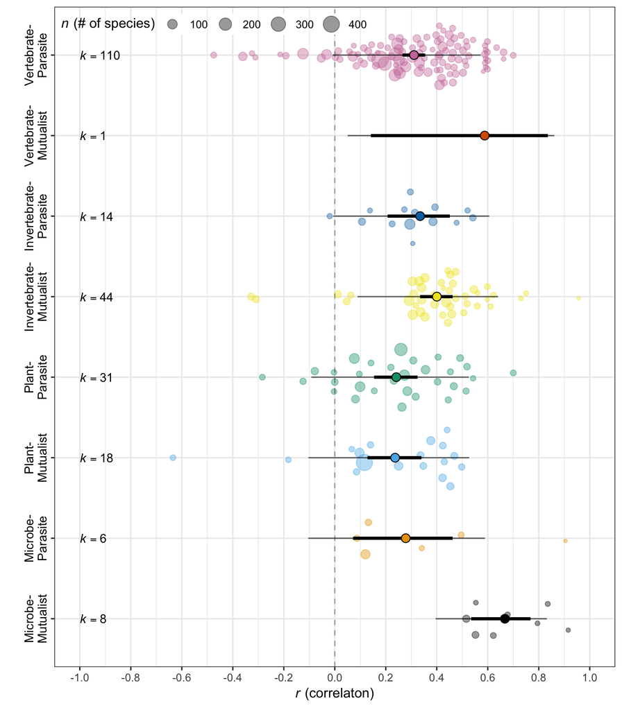

```r
# colour list
colour_ls <- c("#000000", "#E69F00", "#56B4E9", "#009E73",  "#F0E422",  "#0072B2",  "#D55E00", "#CC79A7", "#00008B", "#8B0A50", "#54FF9F", "#999999")

# adding sample size (k) for each category
k_host_tax_symbiosis <- dat %>% group_by(host_tax_symbiosis) %>% count()
# getting estimates and predicitons
pred_host_tax_symbiosis <- get_pred(mr_host_tax_symbiosis1, mod = "host_tax_symbiosis")
res_host_tax_symbiosis1 <- left_join(res_host_tax_symbiosis1, k_host_tax_symbiosis, by =  c("name" = "host_tax_symbiosis"))  %>% left_join(pred_host_tax_symbiosis)
#res_symbiosis1
# drawing a funnel plot - fig 2b
fig_host_tax_symbiosis <- ggplot(data = res_host_tax_symbiosis1, aes(x = tanh(estimate), y = name)) +
  scale_x_continuous(limits=c(-1, 1), breaks = seq(-1, 1, by = 0.2) ) +
  geom_quasirandom(data = dat %>% filter(!is.na(host_tax_symbiosis)),
                   aes(x= tanh(Zr), y = host_tax_symbiosis, size = ((1/VZr) + 3), colour = host_tax_symbiosis), groupOnX = FALSE, alpha=0.4) +
  # 95 %precition interval (PI)
  geom_errorbarh(aes(xmin = tanh(lowerPR), xmax = tanh(upperPR)),  height = 0, show.legend = F, size = 0.5, alpha = 0.6) +
  # 95 %CI
  geom_errorbarh(aes(xmin = tanh(lowerCL), xmax = tanh(upperCL)),  height = 0, show.legend = F, size = 1.2) +
  geom_vline(xintercept = 0, linetype = 2, colour = "black", alpha = 0.3) +
  # creating dots and different size (bee-swarm and bubbles)
  geom_point(aes(fill = name), size = 3, shape = 21) + #
  # setting colours
  scale_color_manual(values =   c("MicrobeMutualist"= colour_ls[1], "MicrobeParasite"= colour_ls[2],  "PlantMutualist"= colour_ls[3], "PlantParasite"= colour_ls[4], "InvertMutualist" = colour_ls[5],  "InvertParasite"= colour_ls[6], "VertMutualist"= colour_ls[7],     "VertParasite"= colour_ls[8] )) +
  scale_fill_manual(values = c("MicrobeMutualist"= colour_ls[1], "MicrobeParasite"= colour_ls[2],  "PlantMutualist"= colour_ls[3], "PlantParasite"= colour_ls[4], "InvertMutualist" = colour_ls[5],  "InvertParasite"= colour_ls[6], "VertMutualist"= colour_ls[7],     "VertParasite"= colour_ls[8] )) +
  scale_y_discrete(labels = c("MicrobeMutualist"= "Microbe-\nMutualist", "MicrobeParasite"= "Microbe-\nParasite",  "PlantMutualist" = "Plant-\nMutualist", "PlantParasite"="Plant-\nParasite", "InvertMutualist" = "Invertebrate-\nMutualist",   "InvertParasite"= "Invertebrate-\nParasite", "VertMutualist"= "Vertebrate-\nMutualist",  "VertParasite"= "Vertebrate-\nParasite" )) +
  annotate('text', x = -1, y = res_host_tax_symbiosis1$name, label= paste("italic(k)==", res_host_tax_symbiosis1$n), parse=TRUE, hjust = "left", size=3.5) +
  labs(x = expression(paste(italic(r), " (correlaton)")), y = "", size = expression(paste(italic(n), " (# of species)")) ) +
  guides(fill = "none", colour = "none") +
  theme_bw() +
  theme(legend.position= c(0, 1), legend.justification = c(0,1)) +
  theme(legend.direction="horizontal") +
  #theme(legend.background = element_rect(fill = "white", colour = "black")) +
  theme(legend.background = element_blank()) +
  theme(axis.text.y = element_text(size = 10, colour ="black", hjust = 0.5, angle = 90))

fig_host_tax_symbiosis
```

#### The combined effect of symbiont taxa and symbiosis (parasitism vs. mutualism)

NOTE - symbiont_tax_symbiosis = 21 combinations

```r
# reordering
dat$symbiont_tax_symbiosis <- factor(dat$symbiont_tax_symbiosis, levels = c("MicrobeMutualist",
    "MicrobeParasite", "PlantMutualist", "PlantParasite", "InvertMutualist",
    "InvertParasite", "VertParasite"))

# meta-regression: multiple intercepts
mr_symbiont_tax_symbiosis1 <- rma.mv(yi = Zr, V = VZr, mods = ~symbiont_tax_symbiosis -
    1, test = "t", random = ~1 | authors, data = dat)

# # meta-regression: contrasts x 10 getting the level names out
level_names <- levels(dat$symbiont_tax_symbiosis)

# helper function to run metafor meta-regression
run_rma <- function(name) {
    rma.mv(yi = Zr, V = VZr, mods = ~relevel(symbiont_tax_symbiosis, ref = name),
        test = "t", random = ~1 | authors, data = dat)
}

# results of meta-regression including all contrast results; taking the last
# level out ([-length(level_names)])
mr_symbiont_tax_symbiosis <- map(level_names[-length(level_names)], run_rma)
```

```r
# getting marginal R2
r2_symbiont_tax_symbiosis1 <- R2(mr_symbiont_tax_symbiosis1)

# getting estimates
res_symbiont_tax_symbiosis1 <- get_est(mr_symbiont_tax_symbiosis1, mod = "symbiont_tax_symbiosis")
res_symbiont_tax_symbiosis <- map(mr_symbiont_tax_symbiosis, ~get_est(.x, mod = "symbiont_tax_symbiosis"))

# a list of the numbers to take out unnecessary contrasts
contra_list <- Map(seq, from = 1, to = 1:6)

# you need to flatten twice: first to make it a list and make it a vector
estiamtes <- map2(res_symbiont_tax_symbiosis, contra_list, ~.x[-(.y), "estimate"]) %>%
    flatten() %>% flatten_dbl()
lowerCLs <- map2(res_symbiont_tax_symbiosis, contra_list, ~.x[-(.y), "lowerCL"]) %>%
    flatten() %>% flatten_dbl()
upperCLs <- map2(res_symbiont_tax_symbiosis, contra_list, ~.x[-(.y), "upperCL"]) %>%
    flatten() %>% flatten_dbl()

# creating a table
tibble(`Fixed effect` = c(as.character(res_symbiont_tax_symbiosis1$name), cont_gen(res_symbiont_tax_symbiosis1$name)),
    Estimate = c(res_symbiont_tax_symbiosis1$estimate, estiamtes), `Lower CI [0.025]` = c(res_symbiont_tax_symbiosis1$lowerCL,
        lowerCLs), `Upper CI  [0.975]` = c(res_symbiont_tax_symbiosis1$upperCL,
        lowerCLs), `V[authors]` = c(mr_symbiont_tax_symbiosis1$sigma2, rep(NA,
        (7 + choose(7, 2)) - 1)), R2 = c(r2_symbiont_tax_symbiosis1[1], rep(NA,
        (7 + choose(7, 2)) - 1))) %>% kable("html", digits = 3) %>% kable_styling("striped",
    position = "left") %>% scroll_box(width = "100%", height = "300px")
```

| Fixed effect | Estimate | Lower CI [0.025] | Upper CI [0.975] | V[authors] | R2 |
| --- | --- | --- | --- | --- | --- |
| MicrobeMutualist | 0.437 | 0.365 | 0.509 | 0.029 | 0.263 |
| MicrobeParasite | 0.279 | 0.213 | 0.345 | NA | NA |
| PlantMutualist | 0.651 | 0.349 | 0.953 | NA | NA |
| PlantParasite | 1.499 | 0.555 | 2.442 | NA | NA |
| InvertMutualist | 0.290 | 0.165 | 0.415 | NA | NA |
| InvertParasite | 0.323 | 0.267 | 0.378 | NA | NA |
| VertParasite | 0.354 | 0.064 | 0.645 | NA | NA |
| MicrobeMutualist-MicrobeParasite | -0.158 | -0.256 | -0.256 | NA | NA |
| MicrobeMutualist-PlantMutualist | 0.214 | -0.097 | -0.097 | NA | NA |
| MicrobeMutualist-PlantParasite | 1.062 | 0.115 | 0.115 | NA | NA |
| MicrobeMutualist-InvertMutualist | -0.147 | -0.292 | -0.292 | NA | NA |
| MicrobeMutualist-InvertParasite | -0.114 | -0.205 | -0.205 | NA | NA |
| MicrobeMutualist-VertParasite | -0.083 | -0.382 | -0.382 | NA | NA |
| MicrobeParasite-PlantMutualist | 0.372 | 0.063 | 0.063 | NA | NA |
| MicrobeParasite-PlantParasite | 1.220 | 0.274 | 0.274 | NA | NA |
| MicrobeParasite-InvertMutualist | 0.011 | -0.130 | -0.130 | NA | NA |
| MicrobeParasite-InvertParasite | 0.044 | -0.042 | -0.042 | NA | NA |
| MicrobeParasite-VertParasite | 0.076 | -0.222 | -0.222 | NA | NA |
| PlantMutualist-PlantParasite | 0.848 | -0.143 | -0.143 | NA | NA |
| PlantMutualist-InvertMutualist | -0.361 | -0.688 | -0.688 | NA | NA |
| PlantMutualist-InvertParasite | -0.328 | -0.635 | -0.635 | NA | NA |
| PlantMutualist-VertParasite | -0.296 | -0.716 | -0.716 | NA | NA |
| PlantParasite-InvertMutualist | -1.209 | -2.161 | -2.161 | NA | NA |
| PlantParasite-InvertParasite | -1.176 | -2.121 | -2.121 | NA | NA |
| PlantParasite-VertParasite | -1.144 | -2.132 | -2.132 | NA | NA |
| InvertMutualist-InvertParasite | 0.033 | -0.100 | -0.100 | NA | NA |
| InvertMutualist-VertParasite | 0.065 | -0.252 | -0.252 | NA | NA |
| InvertParasite-VertParasite | 0.032 | -0.264 | -0.264 | NA | NA |

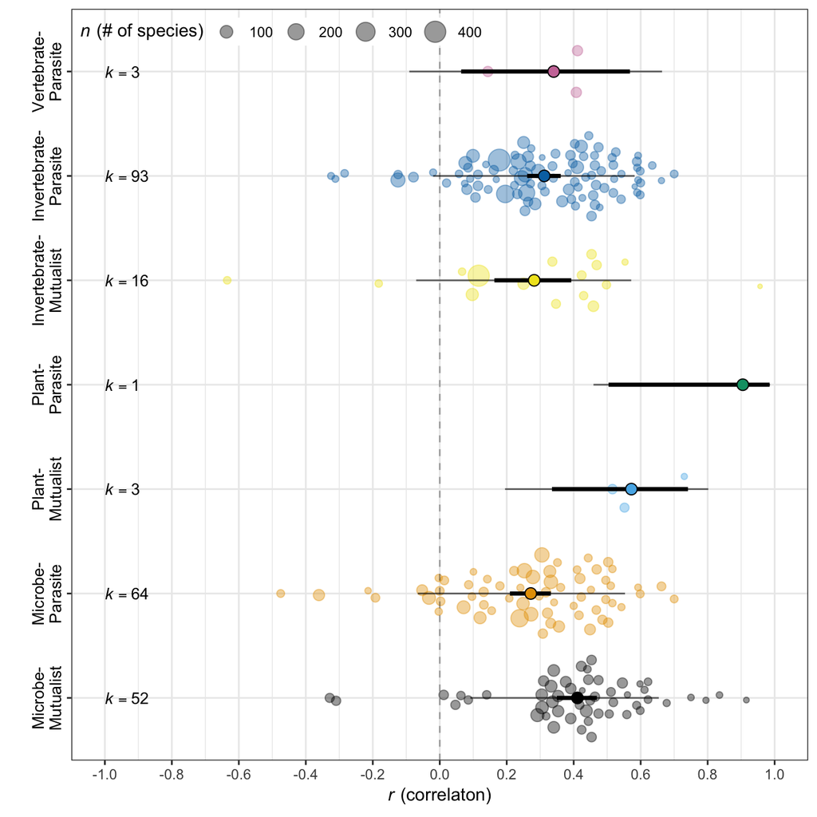

```r
# adding sample size (k) for each category
k_symbiont_tax_symbiosis <- dat %>% group_by(symbiont_tax_symbiosis) %>% count()
# getting estimates and predicitons
pred_symbiont_tax_symbiosis <- get_pred(mr_symbiont_tax_symbiosis1, mod = "symbiont_tax_symbiosis")
res_symbiont_tax_symbiosis1 <- left_join(res_symbiont_tax_symbiosis1, k_symbiont_tax_symbiosis, by =  c("name" = "symbiont_tax_symbiosis"))  %>% left_join(pred_symbiont_tax_symbiosis)
#res_symbiosis1
# drawing a funnel plot - fig 2b
fig_symbiont_tax_symbiosis <- ggplot(data = res_symbiont_tax_symbiosis1, aes(x = tanh(estimate), y = name)) +
  scale_x_continuous(limits=c(-1, 1), breaks = seq(-1, 1, by = 0.2) ) +
  geom_quasirandom(data = dat %>% filter(!is.na(symbiont_tax_symbiosis)),
                   aes(x= tanh(Zr), y = symbiont_tax_symbiosis, size = ((1/VZr) + 3), colour = symbiont_tax_symbiosis), groupOnX = FALSE, alpha=0.4) +
  # 95 %precition interval (PI)
  geom_errorbarh(aes(xmin = tanh(lowerPR), xmax = tanh(upperPR)),  height = 0, show.legend = F, size = 0.5, alpha = 0.6) +
  # 95 %CI
  geom_errorbarh(aes(xmin = tanh(lowerCL), xmax = tanh(upperCL)),  height = 0, show.legend = F, size = 1.2) +
  geom_vline(xintercept = 0, linetype = 2, colour = "black", alpha = 0.3) +
  # creating dots and different size (bee-swarm and bubbles)
  geom_point(aes(fill = name), size = 3, shape = 21) + #
  # setting colours
  # setting colours
  scale_color_manual(values =   c("MicrobeMutualist"= colour_ls[1], "MicrobeParasite"= colour_ls[2],  "PlantMutualist"= colour_ls[3], "PlantParasite"= colour_ls[4], "InvertMutualist" = colour_ls[5],  "InvertParasite"= colour_ls[6], "VertParasite"= colour_ls[8] )) +
  scale_fill_manual(values = c("MicrobeMutualist"= colour_ls[1], "MicrobeParasite"= colour_ls[2],  "PlantMutualist"= colour_ls[3], "PlantParasite"= colour_ls[4], "InvertMutualist" = colour_ls[5],  "InvertParasite"= colour_ls[6], "VertParasite"= colour_ls[8] )) +
  scale_y_discrete(labels = c("MicrobeMutualist"= "Microbe-\nMutualist", "MicrobeParasite"= "Microbe-\nParasite",  "PlantMutualist" = "Plant-\nMutualist", "PlantParasite"="Plant-\nParasite", "InvertMutualist" = "Invertebrate-\nMutualist",   "InvertParasite"= "Invertebrate-\nParasite",  "VertParasite"= "Vertebrate-\nParasite" )) +
  annotate('text', x = -1, y = res_symbiont_tax_symbiosis1$name, label= paste("italic(k)==", res_symbiont_tax_symbiosis1$n), parse=TRUE, hjust = "left", size=3.5) +
  labs(x = expression(paste(italic(r), " (correlaton)")), y = "", size = expression(paste(italic(n), " (# of species)")) ) +
  guides(fill = "none", colour = "none") +
  theme_bw() +
  theme(legend.position= c(0, 1), legend.justification = c(0,1)) +
  theme(legend.direction="horizontal") +
  #theme(legend.background = element_rect(fill = "white", colour = "black")) +
  theme(legend.background = element_blank()) +
  theme(axis.text.y = element_text(size = 10, colour ="black", hjust = 0.5, angle = 90))

fig_symbiont_tax_symbiosis
```

#### The combined effect of host and symbiont taxa

NOTE – host_symbiont_tax - 11 varaibles and 55 combinations!!!!

```r
# reordering
dat$host_symbiont_tax <- factor(dat$host_symbiont_tax, levels = c("MicrobeInvert",
    "MicrobeMicrobe", "MicrobePlant", "PlantInvert", "PlantMicrobe", "InvertInvert",
    "InvertMicrobe", "InvertPlant", "VertInvert", "VertMicrobe", "VertVert"))

# meta-regression: multiple intercepts
mr_host_symbiont_tax1 <- rma.mv(yi = Zr, V = VZr, mods = ~host_symbiont_tax -
    1, test = "t", random = ~1 | authors, data = dat)

# # meta-regression: contrasts x 10 getting the level names out
level_names <- levels(dat$host_symbiont_tax)

# helper function to run metafor meta-regression
run_rma <- function(name) {
    rma.mv(yi = Zr, V = VZr, mods = ~relevel(host_symbiont_tax, ref = name),
        test = "t", random = ~1 | authors, data = dat)
}

# results of meta-regression including all contrast results; taking the last
# level out ([-length(level_names)])
mr_host_symbiont_tax <- map(level_names[-length(level_names)], run_rma)
```

```r
# getting marginal R2
r2_host_symbiont_tax1 <- R2(mr_host_symbiont_tax1)

# getting estimates
res_host_symbiont_tax1 <- get_est(mr_host_symbiont_tax1, mod = "host_symbiont_tax")
res_host_symbiont_tax <- map(mr_host_symbiont_tax, ~get_est(.x, mod = "host_symbiont_tax"))

# a list of the numbers to take out unnecessary contrasts
contra_list <- Map(seq, from = 1, to = 1:10)

# you need to flatten twice: first to make it a list and make it a vector
estiamtes <- map2(res_host_symbiont_tax, contra_list, ~.x[-(.y), "estimate"]) %>%
    flatten() %>% flatten_dbl()

lowerCLs <- map2(res_host_symbiont_tax, contra_list, ~.x[-(.y), "lowerCL"]) %>%
    flatten() %>% flatten_dbl()

upperCLs <- map2(res_host_symbiont_tax, contra_list, ~.x[-(.y), "upperCL"]) %>%
    flatten() %>% flatten_dbl()

# creating a table
tibble(`Fixed effect` = c(as.character(res_host_symbiont_tax1$name), cont_gen(res_host_symbiont_tax1$name)),
    Estimate = c(res_host_symbiont_tax1$estimate, estiamtes), `Lower CI [0.025]` = c(res_host_symbiont_tax1$lowerCL,
        lowerCLs), `Upper CI  [0.975]` = c(res_host_symbiont_tax1$upperCL, lowerCLs),
    `V[authors]` = c(mr_host_tax_symbiosis1$sigma2, rep(NA, (11 + choose(11,
        2)) - 1)), R2 = c(r2_host_symbiont_tax1[1], rep(NA, (11 + choose(11,
        2)) - 1))) %>% kable("html", digits = 3) %>% kable_styling("striped",
    position = "left") %>% scroll_box(width = "100%", height = "300px")
```

| Fixed effect | Estimate | Lower CI [0.025] | Upper CI [0.975] | V[authors] | R2 |
| --- | --- | --- | --- | --- | --- |
| MicrobeInvert | 0.623 | -0.119 | 1.366 | 0.027 | 0.219 |
| MicrobeMicrobe | 0.508 | 0.328 | 0.689 | NA | NA |
| MicrobePlant | 0.696 | 0.379 | 1.012 | NA | NA |
| PlantInvert | 0.216 | 0.119 | 0.312 | NA | NA |
| PlantMicrobe | 0.295 | 0.167 | 0.423 | NA | NA |
| InvertInvert | 0.421 | 0.286 | 0.556 | NA | NA |
| InvertMicrobe | 0.405 | 0.325 | 0.485 | NA | NA |
| InvertPlant | 0.929 | 0.187 | 1.672 | NA | NA |
| VertInvert | 0.353 | 0.284 | 0.421 | NA | NA |
| VertMicrobe | 0.293 | 0.215 | 0.371 | NA | NA |
| VertVert | 0.355 | 0.059 | 0.650 | NA | NA |
| MicrobeInvert-MicrobeMicrobe | -0.115 | -0.879 | -0.879 | NA | NA |
| MicrobeInvert-MicrobePlant | 0.072 | -0.735 | -0.735 | NA | NA |
| MicrobeInvert-PlantInvert | -0.408 | -1.156 | -1.156 | NA | NA |
| MicrobeInvert-PlantMicrobe | -0.328 | -1.082 | -1.082 | NA | NA |
| MicrobeInvert-InvertInvert | -0.202 | -0.957 | -0.957 | NA | NA |
| MicrobeInvert-InvertMicrobe | -0.218 | -0.965 | -0.965 | NA | NA |
| MicrobeInvert-InvertPlant | 0.306 | -0.744 | -0.744 | NA | NA |
| MicrobeInvert-VertInvert | -0.271 | -1.016 | -1.016 | NA | NA |
| MicrobeInvert-VertMicrobe | -0.330 | -1.077 | -1.077 | NA | NA |
| MicrobeInvert-VertVert | -0.269 | -1.068 | -1.068 | NA | NA |
| MicrobeMicrobe-MicrobePlant | 0.187 | -0.177 | -0.177 | NA | NA |
| MicrobeMicrobe-PlantInvert | -0.293 | -0.498 | -0.498 | NA | NA |
| MicrobeMicrobe-PlantMicrobe | -0.213 | -0.435 | -0.435 | NA | NA |
| MicrobeMicrobe-InvertInvert | -0.087 | -0.313 | -0.313 | NA | NA |
| MicrobeMicrobe-InvertMicrobe | -0.103 | -0.301 | -0.301 | NA | NA |
| MicrobeMicrobe-InvertPlant | 0.421 | -0.343 | -0.343 | NA | NA |
| MicrobeMicrobe-VertInvert | -0.156 | -0.349 | -0.349 | NA | NA |
| MicrobeMicrobe-VertMicrobe | -0.215 | -0.412 | -0.412 | NA | NA |
| MicrobeMicrobe-VertVert | -0.154 | -0.500 | -0.500 | NA | NA |
| MicrobePlant-PlantInvert | -0.480 | -0.811 | -0.811 | NA | NA |
| MicrobePlant-PlantMicrobe | -0.401 | -0.742 | -0.742 | NA | NA |
| MicrobePlant-InvertInvert | -0.275 | -0.619 | -0.619 | NA | NA |
| MicrobePlant-InvertMicrobe | -0.290 | -0.617 | -0.617 | NA | NA |
| MicrobePlant-InvertPlant | 0.234 | -0.573 | -0.573 | NA | NA |
| MicrobePlant-VertInvert | -0.343 | -0.667 | -0.667 | NA | NA |
| MicrobePlant-VertMicrobe | -0.403 | -0.728 | -0.728 | NA | NA |
| MicrobePlant-VertVert | -0.341 | -0.774 | -0.774 | NA | NA |
| PlantInvert-PlantMicrobe | 0.080 | -0.081 | -0.081 | NA | NA |
| PlantInvert-InvertInvert | 0.205 | 0.039 | 0.039 | NA | NA |
| PlantInvert-InvertMicrobe | 0.190 | 0.064 | 0.064 | NA | NA |
| PlantInvert-InvertPlant | 0.714 | -0.035 | -0.035 | NA | NA |
| PlantInvert-VertInvert | 0.137 | 0.019 | 0.019 | NA | NA |
| PlantInvert-VertMicrobe | 0.078 | -0.047 | -0.047 | NA | NA |
| PlantInvert-VertVert | 0.139 | -0.172 | -0.172 | NA | NA |
| PlantMicrobe-InvertInvert | 0.126 | -0.060 | -0.060 | NA | NA |
| PlantMicrobe-InvertMicrobe | 0.110 | -0.041 | -0.041 | NA | NA |
| PlantMicrobe-InvertPlant | 0.634 | -0.119 | -0.119 | NA | NA |
| PlantMicrobe-VertInvert | 0.058 | -0.088 | -0.088 | NA | NA |
| PlantMicrobe-VertMicrobe | -0.002 | -0.152 | -0.152 | NA | NA |
| PlantMicrobe-VertVert | 0.060 | -0.262 | -0.262 | NA | NA |
| InvertInvert-InvertMicrobe | -0.015 | -0.172 | -0.172 | NA | NA |
| InvertInvert-InvertPlant | 0.508 | -0.246 | -0.246 | NA | NA |
| InvertInvert-VertInvert | -0.068 | -0.213 | -0.213 | NA | NA |
| InvertInvert-VertMicrobe | -0.128 | -0.284 | -0.284 | NA | NA |
| InvertInvert-VertVert | -0.066 | -0.391 | -0.391 | NA | NA |
| InvertMicrobe-InvertPlant | 0.524 | -0.223 | -0.223 | NA | NA |
| InvertMicrobe-VertInvert | -0.053 | -0.158 | -0.158 | NA | NA |
| InvertMicrobe-VertMicrobe | -0.112 | -0.224 | -0.224 | NA | NA |
| InvertMicrobe-VertVert | -0.051 | -0.357 | -0.357 | NA | NA |
| InvertPlant-VertInvert | -0.577 | -1.322 | -1.322 | NA | NA |
| InvertPlant-VertMicrobe | -0.636 | -1.383 | -1.383 | NA | NA |
| InvertPlant-VertVert | -0.575 | -1.374 | -1.374 | NA | NA |
| VertInvert-VertMicrobe | -0.060 | -0.163 | -0.163 | NA | NA |
| VertInvert-VertVert | 0.002 | -0.301 | -0.301 | NA | NA |
| VertMicrobe-VertVert | 0.061 | -0.244 | -0.244 | NA | NA |

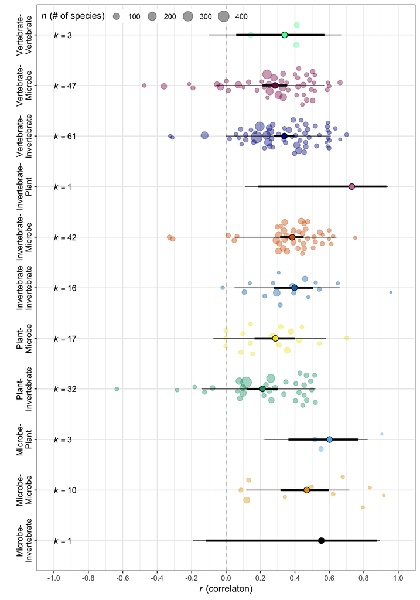

```r
# colour list
#colour_ls <- c("#000000", "#E69F00", "#56B4E9", "#009E73",  "#F0E422",  "#0072B2",  "#D55E00", "#CC79A7", "#00008B", "#8B0A50", "#54FF9F", "#999999")

# adding sample size (k) for each category
k_host_symbiont_tax <- dat %>% group_by(host_symbiont_tax) %>% count()
# getting estimates and predicitons
pred_host_symbiont_tax <- get_pred(mr_host_symbiont_tax1, mod = "host_symbiont_tax")
res_host_symbiont_tax1 <- left_join(res_host_symbiont_tax1, k_host_symbiont_tax, by =  c("name" = "host_symbiont_tax"))  %>% left_join(pred_host_symbiont_tax)
#res_symbiosis1
# drawing a funnel plot - fig 2b
fig_host_symbiont_tax <- ggplot(data = res_host_symbiont_tax1, aes(x = tanh(estimate), y = name)) +
  scale_x_continuous(limits=c(-1, 1), breaks = seq(-1, 1, by = 0.2) ) +
  geom_quasirandom(data = dat %>% filter(!is.na(host_symbiont_tax)),
                   aes(x= tanh(Zr), y = host_symbiont_tax, size = ((1/VZr) + 3), colour = host_symbiont_tax), groupOnX = FALSE, alpha=0.4) +
  # 95 %precition interval (PI)
  geom_errorbarh(aes(xmin = tanh(lowerPR), xmax = tanh(upperPR)),  height = 0, show.legend = F, size = 0.5, alpha = 0.6) +
  # 95 %CI
  geom_errorbarh(aes(xmin = tanh(lowerCL), xmax = tanh(upperCL)),  height = 0, show.legend = F, size = 1.2) +
  geom_vline(xintercept = 0, linetype = 2, colour = "black", alpha = 0.3) +
  # creating dots and different size (bee-swarm and bubbles)
  geom_point(aes(fill = name), size = 3, shape = 21) + #
  # setting colours
  scale_color_manual(values =  c("MicrobeInvert" = colour_ls[1],  "MicrobeMicrobe"= colour_ls[2], "MicrobePlant" = colour_ls[3], "PlantInvert" = colour_ls[4],"PlantMicrobe" = colour_ls[5], "InvertInvert"  = colour_ls[6],  "InvertMicrobe" = colour_ls[7], "InvertPlant" = colour_ls[8],"VertInvert"  = colour_ls[9], "VertMicrobe"= colour_ls[10],"VertVert"  = colour_ls[11])) +
  scale_fill_manual(values = c("MicrobeInvert" = colour_ls[1],  "MicrobeMicrobe"= colour_ls[2], "MicrobePlant" = colour_ls[3], "PlantInvert" = colour_ls[4],"PlantMicrobe" = colour_ls[5], "InvertInvert"  = colour_ls[6],  "InvertMicrobe" = colour_ls[7], "InvertPlant" = colour_ls[8],"VertInvert"  = colour_ls[9], "VertMicrobe"= colour_ls[10],"VertVert"  = colour_ls[11])) +
  scale_y_discrete(labels = c("MicrobeInvert" = "Microbe-\nInvertebrate",  "MicrobeMicrobe"= "Microbe-\nMicrobe", "MicrobePlant" = "Microbe-\nPlant", "PlantInvert" = "Plant-\nInvertebrate","PlantMicrobe" = "Plant-\nMicrobe", "InvertInvert"  = "Invertebrate\nInvertebrate",  "InvertMicrobe" = "Invertebrate-\nMicrobe", "InvertPlant" = "Invertebrate-\nPlant","VertInvert"  = "Vertebrate-\nInvertebrate", "VertMicrobe"= "Vertebrate-\nMicrobe", "VertVert"  = "Vertebrate-\nVertebrate")) +
  annotate('text', x = -1, y = res_host_symbiont_tax1$name, label= paste("italic(k)==", res_host_symbiont_tax1$n), parse=TRUE, hjust = "left", size=3.5) +
  labs(x = expression(paste(italic(r), " (correlaton)")), y = "", size = expression(paste(italic(n), " (# of species)")) ) +
  guides(fill = "none", colour = "none") +
  theme_bw() +
  theme(legend.position= c(0, 1), legend.justification = c(0,1)) +
  theme(legend.direction="horizontal") +
  #theme(legend.background = element_rect(fill = "white", colour = "black")) +
  theme(legend.background = element_blank()) +
  theme(axis.text.y = element_text(size = 10, colour ="black", hjust = 0.5, angle = 90))

fig_host_symbiont_tax
```

#### The combined effect of symbiosis and mode of transmission

```r
dat$symbiosis_transmission <- factor(dat$symbiosis_transmission, levels = c("Mutualistboth",
    "Mutualisthorizontal", "Mutualistvertical", "Parasiteboth", "Parasitehorizontal"),
    labels = c("MutualistBoth", "MutualistHorizontal", "MutualistVertical",
        "ParasiteBoth", "ParasiteHorizontal"))

# meta-regression: mutiple intercepts
mr_symbiosis_transmission1 <- rma.mv(yi = Zr, V = VZr, mods = ~symbiosis_transmission -
    1, test = "t", random = ~1 | authors, data = dat)

# # meta-regression: contrasts x 10 getting the level names out
level_names <- levels(dat$symbiosis_transmission)

# helper function to run metafor meta-regression
run_rma <- function(name) {
    rma.mv(yi = Zr, V = VZr, mods = ~relevel(symbiosis_transmission, ref = name),
        test = "t", random = ~1 | authors, data = dat)
}

# results of meta-regression including all contrast results; taking the last
# level out ([-length(level_names)])
mr_symbiosis_transmission <- map(level_names[-length(level_names)], run_rma)
```

```r
# getting marginal R2
r2_symbiosis_transmission1 <- R2(mr_symbiosis_transmission1)

# getting estimates
res_symbiosis_transmission1 <- get_est(mr_symbiosis_transmission1, mod = "symbiosis_transmission")
res_symbiosis_transmission <- map(mr_symbiosis_transmission, ~get_est(.x, mod = "symbiosis_transmission"))

# a list of the numbers to take out unnecessary contrasts
contra_list <- Map(seq, from = 1, to = 1:4)

# you need to flatten twice: first to make it a list and make it a vector
estiamtes <- map2(res_symbiosis_transmission, contra_list, ~.x[-(.y), "estimate"]) %>%
    flatten() %>% flatten_dbl()
lowerCLs <- map2(res_symbiosis_transmission, contra_list, ~.x[-(.y), "lowerCL"]) %>%
    flatten() %>% flatten_dbl()
upperCLs <- map2(res_symbiosis_transmission, contra_list, ~.x[-(.y), "upperCL"]) %>%
    flatten() %>% flatten_dbl()

# creating a table
tibble(`Fixed effect` = c(as.character(res_symbiosis_transmission1$name), cont_gen(res_symbiosis_transmission1$name)),
    Estimate = c(res_symbiosis_transmission1$estimate, estiamtes), `Lower CI [0.025]` = c(res_symbiosis_transmission1$lowerCL,
        lowerCLs), `Upper CI  [0.975]` = c(res_symbiosis_transmission1$upperCL,
        lowerCLs), `V[authors]` = c(mr_symbiosis_transmission1$sigma2, rep(NA,
        (5 + choose(5, 2)) - 1)), R2 = c(r2_symbiosis_transmission1[1], rep(NA,
        (5 + choose(5, 2)) - 1))) %>% kable("html", digits = 3) %>% kable_styling("striped",
    position = "left") %>% scroll_box(width = "100%", height = "300px")
```

| Fixed effect | Estimate | Lower CI [0.025] | Upper CI [0.975] | V[authors] | R2 |
| --- | --- | --- | --- | --- | --- |
| MutualistBoth | 0.453 | 0.224 | 0.682 | 0.024 | 0.213 |
| MutualistHorizontal | 0.290 | 0.189 | 0.391 | NA | NA |
| MutualistVertical | 0.493 | 0.417 | 0.568 | NA | NA |
| ParasiteBoth | 0.362 | 0.285 | 0.439 | NA | NA |
| ParasiteHorizontal | 0.284 | 0.238 | 0.331 | NA | NA |
| MutualistBoth-MutualistHorizontal | -0.163 | -0.413 | -0.413 | NA | NA |
| MutualistBoth-MutualistVertical | 0.040 | -0.201 | -0.201 | NA | NA |
| MutualistBoth-ParasiteBoth | -0.091 | -0.333 | -0.333 | NA | NA |
| MutualistBoth-ParasiteHorizontal | -0.168 | -0.402 | -0.402 | NA | NA |
| MutualistHorizontal-MutualistVertical | 0.202 | 0.076 | 0.076 | NA | NA |
| MutualistHorizontal-ParasiteBoth | 0.071 | -0.056 | -0.056 | NA | NA |
| MutualistHorizontal-ParasiteHorizontal | -0.006 | -0.115 | -0.115 | NA | NA |
| MutualistVertical-ParasiteBoth | -0.131 | -0.239 | -0.239 | NA | NA |
| MutualistVertical-ParasiteHorizontal | -0.208 | -0.297 | -0.297 | NA | NA |
| ParasiteBoth-ParasiteHorizontal | -0.077 | -0.167 | -0.167 | NA | NA |

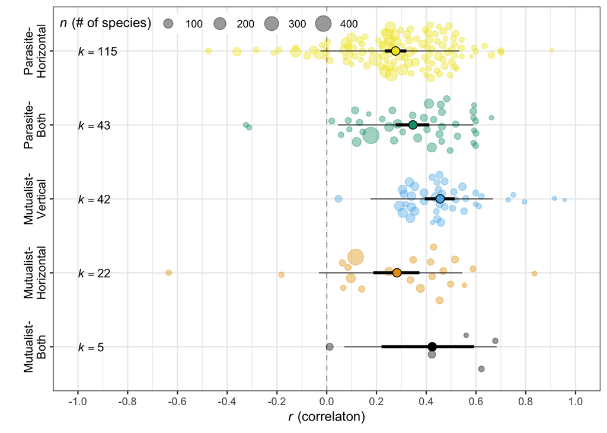

```r
# adding sample size (k) for each category
k_symbiosis_transmission <- dat %>% group_by(symbiosis_transmission) %>% count()
# getting estimates and predicitons
pred_symbiosis_transmission <- get_pred(mr_symbiosis_transmission1, mod = "symbiosis_transmission")
res_symbiosis_transmission1 <- left_join(res_symbiosis_transmission1, k_symbiosis_transmission, by =  c("name" = "symbiosis_transmission"))  %>% left_join(pred_symbiosis_transmission)
#res_symbiosis1
# drawing a funnel plot - fig 2b
fig_symbiosis_transmission <- ggplot(data = res_symbiosis_transmission1, aes(x = tanh(estimate), y = name)) +
  scale_x_continuous(limits=c(-1, 1), breaks = seq(-1, 1, by = 0.2) ) +
  geom_quasirandom(data = dat %>% filter(!is.na(symbiosis_transmission)),
                   aes(x= tanh(Zr), y = symbiosis_transmission, size = ((1/VZr) + 3), colour = symbiosis_transmission), groupOnX = FALSE, alpha=0.4) +
  # 95 %precition interval (PI)
  geom_errorbarh(aes(xmin = tanh(lowerPR), xmax = tanh(upperPR)),  height = 0, show.legend = F, size = 0.5, alpha = 0.6) +
  # 95 %CI
  geom_errorbarh(aes(xmin = tanh(lowerCL), xmax = tanh(upperCL)),  height = 0, show.legend = F, size = 1.2) +
  geom_vline(xintercept = 0, linetype = 2, colour = "black", alpha = 0.3) +
  # creating dots and different size (bee-swarm and bubbles)
  geom_point(aes(fill = name), size = 3, shape = 21) + #
  # setting colours
  scale_color_manual(values =   c("MutualistBoth"= colour_ls[1], "MutualistHorizontal"= colour_ls[2], "MutualistVertical" = colour_ls[3],"ParasiteBoth"= colour_ls[4], "ParasiteHorizontal" = colour_ls[5])) +
  scale_fill_manual(values = c("MutualistBoth"= colour_ls[1], "MutualistHorizontal"= colour_ls[2], "MutualistVertical" = colour_ls[3],"ParasiteBoth"= colour_ls[4], "ParasiteHorizontal" = colour_ls[5])) +
  scale_y_discrete(labels = c("MutualistBoth" = "Mutualist-\nBoth", "MutualistHorizontal" = "Mutualist-\nHorizontal","MutualistVertical" = "Mutualist-\nVertical", "ParasiteBoth" = "Parasite-\nBoth", "ParasiteHorizontal" = "Parasite-\nHorizontal")) +
  annotate('text', x = -1, y = res_symbiosis_transmission1$name, label= paste("italic(k)==", res_symbiosis_transmission1$n), parse=TRUE, hjust = "left", size=3.5) +
  labs(x = expression(paste(italic(r), " (correlaton)")), y = "", size = expression(paste(italic(n), " (# of species)")) ) +
  guides(fill = "none", colour = "none") +
  theme_bw() +
  theme(legend.position= c(0, 1), legend.justification = c(0,1)) +
  theme(legend.direction="horizontal") +
  #theme(legend.background = element_rect(fill = "white", colour = "black")) +
  theme(legend.background = element_blank()) +
  theme(axis.text.y = element_text(size = 10, colour ="black", hjust = 0.5, angle = 90))

fig_symbiosis_transmission
```

NOTE!!! * Do the REF REF REF * Justification of the use of combined datasets…. - done * just do the main one for all three datasets but not others * or we could - provide forest plots of all the three datasets???? (do it later) * heterogeneity - done

- one-by-one analyses here…

## Publication Bias and Sensitivity Analysis

- boundary problems
- Time lag bias

### Recommendation

- they need to run more simuations so they do not max out!
- reanalysis of earlier trees are necessary; getting older or updated trees are required
- new studies should provide all data avaiable online so that future analysis can incorprate all avaiable data

## Refererences

**R version 3.6.0 (2019-04-26)**

**Platform:** x86_64-apple-darwin15.6.0 (64-bit)

**locale:** en_AU.UTF-8||en_AU.UTF-8||en_AU.UTF-8||C||en_AU.UTF-8||en_AU.UTF-8

**attached base packages:** *stats*, *graphics*, *grDevices*, *utils*, *datasets*, *methods* and *base*

**other attached packages:** *plotly(v.4.9.0)*, *ggbeeswarm(v.0.6.0)*, *MCMCglmm(v.2.29)*, *ape(v.5.3)*, *coda(v.0.19-2)*, *metafor(v.2.1-0)*, *Matrix(v.1.2-17)*, *pander(v.0.6.3)*, *magrittr(v.1.5)*, *gridExtra(v.2.3)*, *kableExtra(v.1.1.0)*, *forcats(v.0.4.0)*, *stringr(v.1.4.0)*, *dplyr(v.0.8.1)*, *purrr(v.0.3.2)*, *readr(v.1.3.1)*, *tidyr(v.0.8.3)*, *tibble(v.2.1.1)*, *ggplot2(v.3.1.1)* and *tidyverse(v.1.2.1)*

**loaded via a namespace (and not attached):** *Rcpp(v.1.0.1)*, *lubridate(v.1.7.4)*, *lattice(v.0.20-38)*, *corpcor(v.1.6.9)*, *assertthat(v.0.2.1)*, *digest(v.0.6.19)*, *R6(v.2.4.0)*, *cellranger(v.1.1.0)*, *plyr(v.1.8.4)*, *backports(v.1.1.4)*, *evaluate(v.0.14)*, *highr(v.0.8)*, *httr(v.1.4.0)*, *pillar(v.1.4.1)*, *rlang(v.0.3.4)*, *lazyeval(v.0.2.2)*, *readxl(v.1.3.1)*, *data.table(v.1.12.2)*, *cubature(v.2.0.3)*, *rstudioapi(v.0.10.0-9000)*, *rmarkdown(v.1.13)*, *labeling(v.0.3)*, *webshot(v.0.5.1)*, *htmlwidgets(v.1.3)*, *munsell(v.0.5.0)*, *broom(v.0.5.2)*, *compiler(v.3.6.0)*, *vipor(v.0.4.5)*, *modelr(v.0.1.4)*, *xfun(v.0.7)*, *pkgconfig(v.2.0.2)*, *base64enc(v.0.1-3)*, *htmltools(v.0.3.6)*, *tidyselect(v.0.2.5)*, *tensorA(v.0.36.1)*, *codetools(v.0.2-16)*, *viridisLite(v.0.3.0)*, *crayon(v.1.3.4)*, *withr(v.2.1.2)*, *grid(v.3.6.0)*, *nlme(v.3.1-140)*, *jsonlite(v.1.6)*, *gtable(v.0.3.0)*, *pacman(v.0.5.1)*, *formatR(v.1.6)*, *scales(v.1.0.0)*, *cli(v.1.1.0)*, *stringi(v.1.4.3)*, *xml2(v.1.2.0)*, *generics(v.0.0.2)*, *tools(v.3.6.0)*, *glue(v.1.3.1)*, *beeswarm(v.0.2.3)*, *hms(v.0.4.2)*, *parallel(v.3.6.0)*, *yaml(v.2.2.0)*, *colorspace(v.1.4-1)*, *rvest(v.0.3.4)*, *knitr(v.1.23)* and *haven(v.2.1.0)*